# Using SARIMA Models to Forecast Ontario Retail Food Prices Based on Jan 2017 - Oct 2022 Data

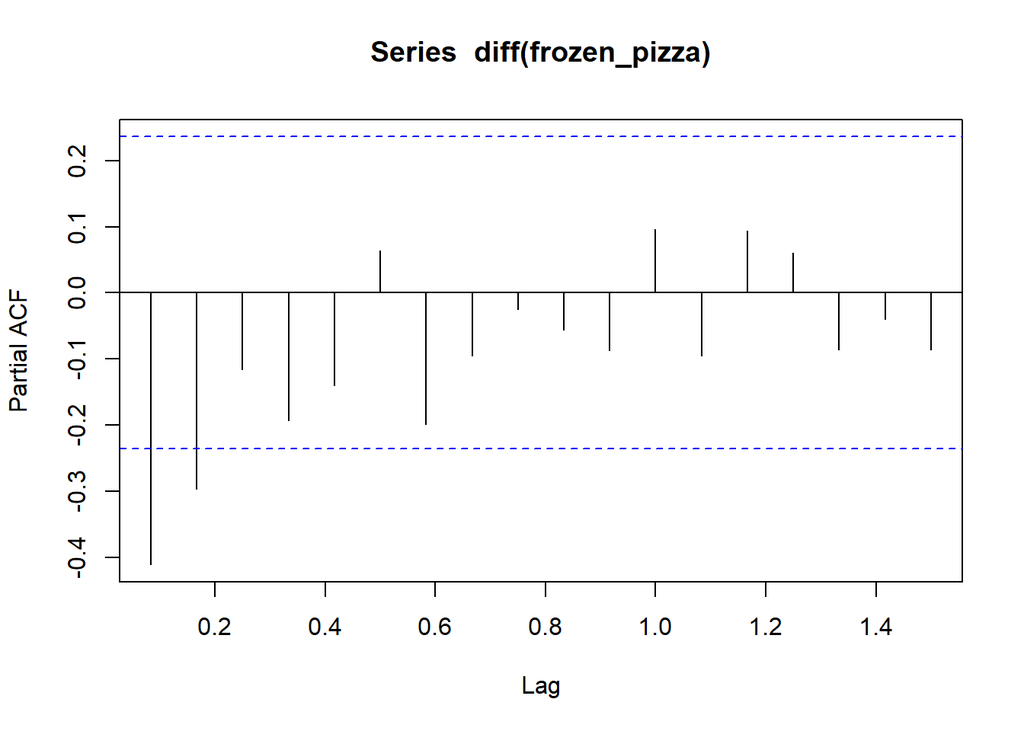

```r
pacf(diff(frozen_pizza))
```

We build a SARIMA model for the frozen pizza prices. It turns out that an ARIMA(0,1,1) model is the best.

```r
frozen_pizza_sarima <- auto.arima(frozen_pizza)
summary(frozen_pizza_sarima)
```

```
## Series: frozen_pizza
## ARIMA(0,1,1)
##
## Coefficients:
##           ma1
##       -0.8501
## s.e.   0.0704
##
## sigma^2 = 0.02567:  log likelihood = 28.31
## AIC=-52.62   AICc=-52.44   BIC=-48.15
##
## Training set error measures:
##                      ME      RMSE       MAE       MPE     MAPE     MASE
## Training set 0.01476904 0.1579143 0.1204058 0.2299641 2.994846 0.752536
##                    ACF1
## Training set 0.08852916
```

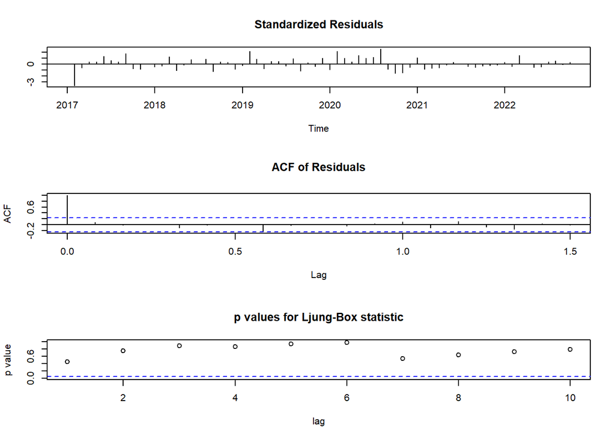

```r
tsdiag(frozen_pizza_sarima)
```

We forecast the frozen pizza prices for the next 14 months.

```r
forecast(frozen_pizza_sarima, 14)
```

```
##          Point Forecast    Lo 80    Hi 80    Lo 95    Hi 95
## Nov 2022       4.089869 3.884539 4.295199 3.775844 4.403894
## Dec 2022       4.089869 3.882245 4.297494 3.772335 4.407403
## Jan 2023       4.089869 3.879976 4.299763 3.768865 4.410874
## Feb 2023       4.089869 3.877731 4.302008 3.765432 4.414307
## Mar 2023       4.089869 3.875509 4.304229 3.762034 4.417705
## Apr 2023       4.089869 3.873311 4.306428 3.758672 4.421067
## May 2023       4.089869 3.871134 4.308605 3.755343 4.424396
## Jun 2023       4.089869 3.868979 4.310760 3.752047 4.427692
## Jul 2023       4.089869 3.866845 4.312894 3.748783 4.430956
## Aug 2023       4.089869 3.864731 4.315008 3.745549 4.434189
## Sep 2023       4.089869 3.862636 4.317102 3.742346 4.437392
## Oct 2023       4.089869 3.860561 4.319178 3.739172 4.440566
## Nov 2023       4.089869 3.858504 4.321234 3.736027 4.443712
## Dec 2023       4.089869 3.856466 4.323273 3.732909 4.446829
```

```r
forecast(frozen_pizza_sarima, 14)-> forecast_frozen_pizzadf
frozen_pizza_forecasts <- cbind(forecast_frozen_pizzadf$mean, forecast_frozen_pizzadf$lower[,2], forecast_frozen_pizzadf$upper[,2])
colnames(frozen_pizza_forecasts) <- c("Forecasted Frozen Pizza Price", "Lower bound 95% CI", "Upper bound 95% CI")
frozen_pizza_forecasts
```

```
##          Forecasted Frozen Pizza Price Lower bound 95% CI Upper bound 95% CI
## Nov 2022                      4.089869           3.775844           4.403894
## Dec 2022                      4.089869           3.772335           4.407403
## Jan 2023                      4.089869           3.768865           4.410874
## Feb 2023                      4.089869           3.765432           4.414307
## Mar 2023                      4.089869           3.762034           4.417705
## Apr 2023                      4.089869           3.758672           4.421067
## May 2023                      4.089869           3.755343           4.424396
## Jun 2023                      4.089869           3.752047           4.427692
## Jul 2023                      4.089869           3.748783           4.430956
## Aug 2023                      4.089869           3.745549           4.434189
## Sep 2023                      4.089869           3.742346           4.437392
## Oct 2023                      4.089869           3.739172           4.440566
## Nov 2023                      4.089869           3.736027           4.443712
## Dec 2023                      4.089869           3.732909           4.446829
```

Perhaps the frozen pizza prices were forecasted to be very similar over the next year, because historically, there hadn’t been drastic variation in the prices. The standard deviation of the pizza prices was only $0.17. Perhaps the companies can keep the price of the frozen pizza more consistent because they can get a bulk deal on ingredients like flour and tomato sauce, which are available all year round, and can be stored for relatively long periods of time. Also, they can mass produce frozen pizza using industrial equipment in factories regardless of the season.

# Bacon

The prices are for each unit of bacon, which weighs 500 grams. This is approximately the weight of a regular package of bacon.

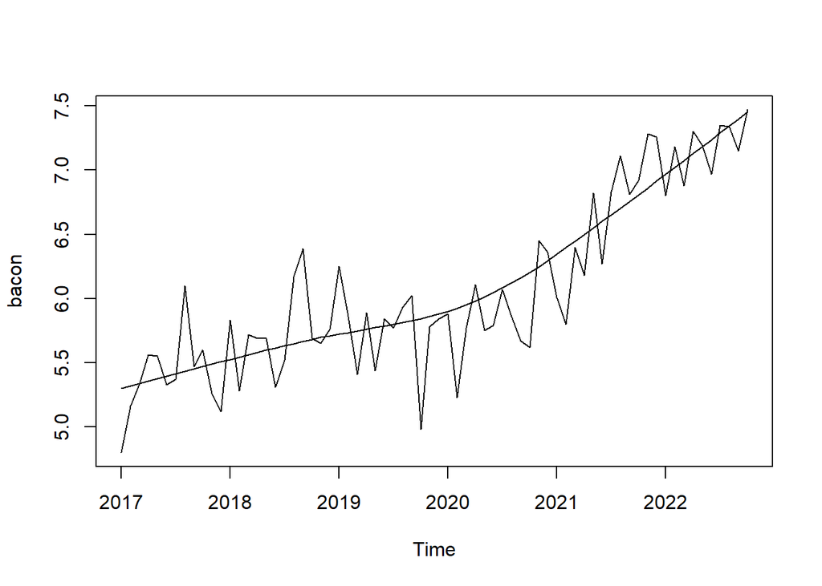

```r
plot.ts(bacon)
lines(lowess(bacon))
```

```r
auto.arima(bacon)
```

```
## Series: bacon
## ARIMA(0,1,1)(0,0,1)[12] with drift
##
## Coefficients:
##           ma1    sma1   drift
##       -0.7182  0.4738  0.0311
## s.e.   0.0801  0.1565  0.0145
##
## sigma^2 = 0.09114:  log likelihood = -15.61
## AIC=39.23   AICc=39.85   BIC=48.16
```

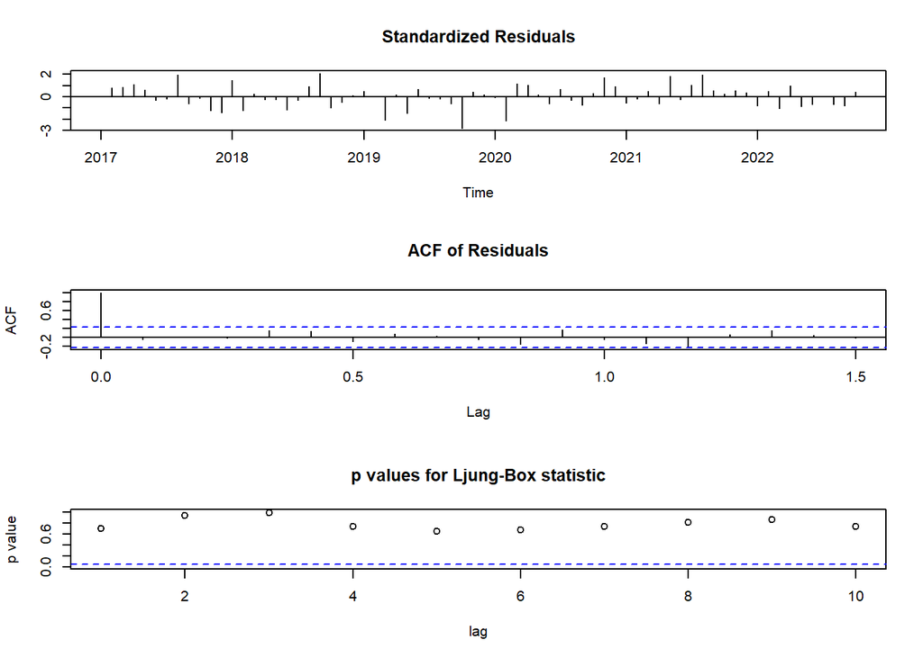

```r
tsdiag(auto.arima(bacon))
```

```r
forecast(auto.arima(bacon),14)-> bacondf
bacon_forecasts <- cbind(bacondf$mean, bacondf$lower[,2], bacondf$upper[,2])
colnames(bacon_forecasts) <- c("Forecasted Bacon Price", "Lower bound 95% CI", "Upper bound 95% CI")
bacon_forecasts
```

```
##          Forecasted Bacon Price Lower bound 95% CI Upper bound 95% CI
## Nov 2022               7.455791           6.864058           8.047524
## Dec 2022               7.485938           6.871157           8.100718
## Jan 2023               7.364740           6.727758           8.001722
## Feb 2023               7.547924           6.889478           8.206369
## Mar 2023               7.380471           6.701239           8.059702
## Apr 2023               7.659575           6.960175           8.358975
## May 2023               7.469341           6.750338           8.188344
## Jun 2023               7.487341           6.749255           8.225426
## Jul 2023               7.600526           6.843839           8.357212
## Aug 2023               7.532222           6.757380           8.307063
## Sep 2023               7.516586           6.724005           8.309167
## Oct 2023               7.694222           6.884290           8.504153
## Nov 2023               7.678181           6.753032           8.603330
## Dec 2023               7.709328           6.752094           8.666562
```

# Avocado

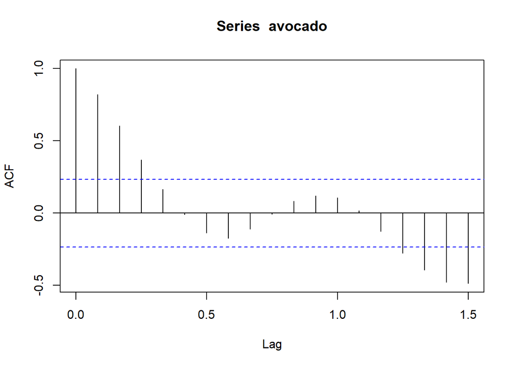

```r
acf(avocado)
```

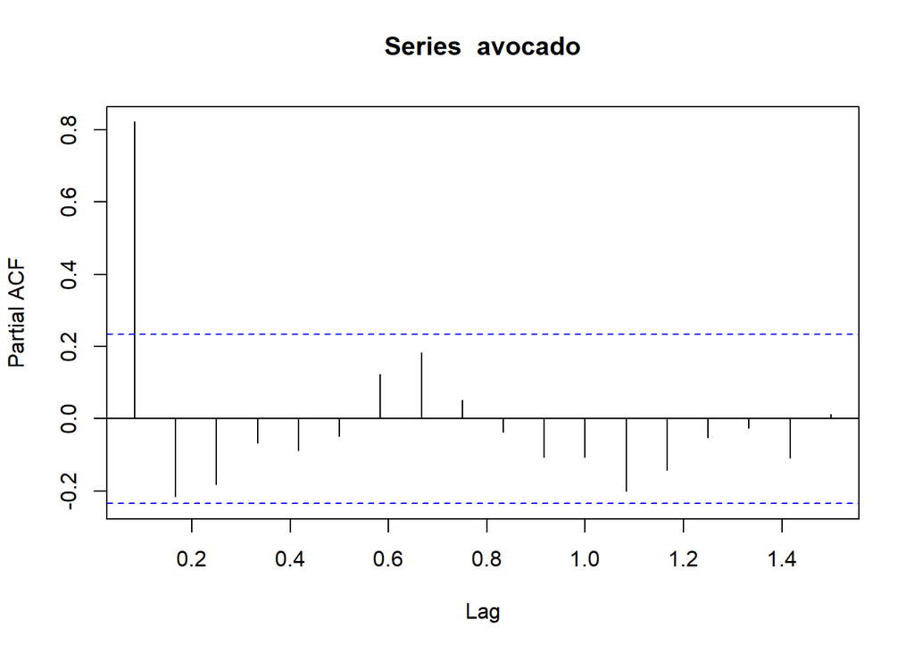

```r
pacf(avocado)
```

# Cantaloupe

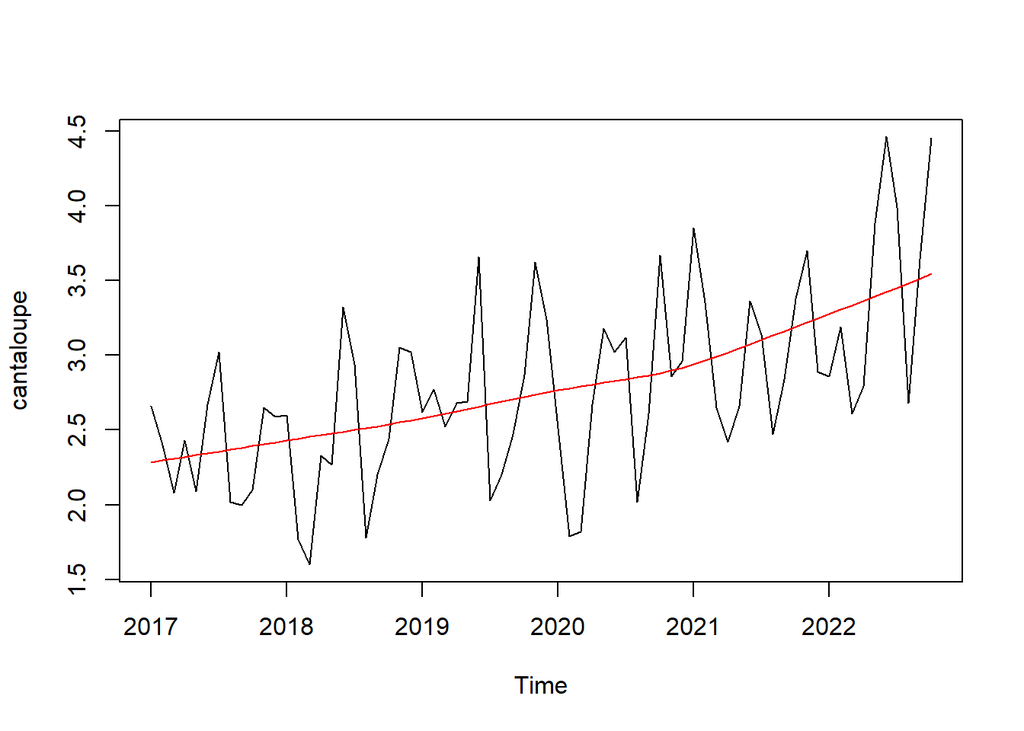

```r
plot.ts(cantaloupe)
lines(lowess(cantaloupe), col = "red")
```

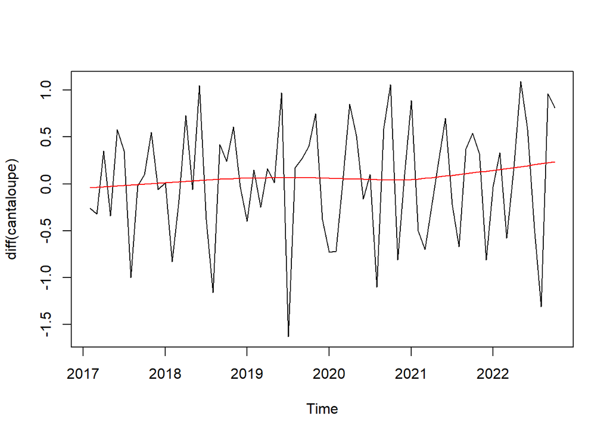

```r
plot.ts(diff(cantaloupe))
lines(lowess(diff(cantaloupe)), col = "red")
```

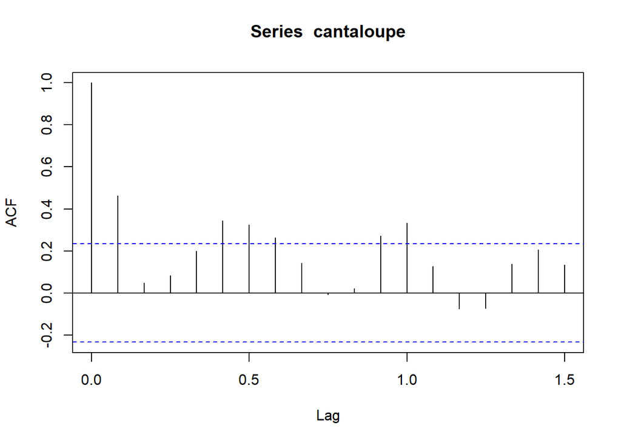

```r
acf(cantaloupe)
```

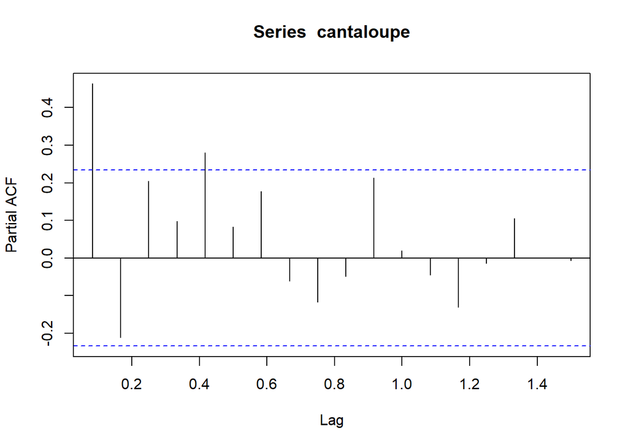

```r
pacf(cantaloupe)
```